# therMizer extension

## Load libraries

Mizer 2.0.1 updated at 23/05/2020 or later version is needed to use the background extension.

A. First and best option: download the most updated version of the package directly from GitHub using devtools::install_github(“sizespectrum/mizer”)

B. Second option: merge upstream master with your branch and upload code from local repository

```r
rm(list=ls())

# option A
# devtools::install_github("sizespectrum/mizer") # run only once
library(mizer)

# option 2
# library(Jmisc)
# path<-"/Users/nov017/R-projects/Mizer-trait/R"
# sourceAll(path)
```

## Set up multispecies model

All parameters are made up

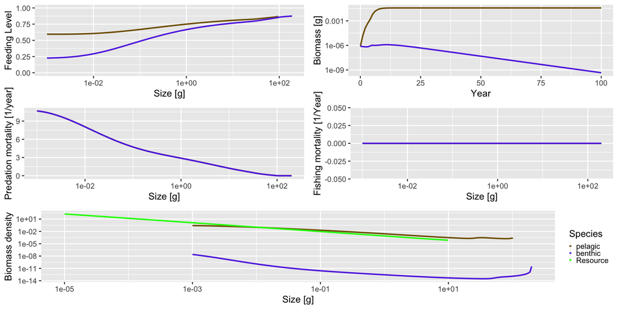

```r
species_params = data.frame(species = c("pelagic", "benthic"), w_inf = c(100, 200), k_vb =c(0.2, 0.2), w_min = c(0.001, 0.001))

# available PP to species
species_params$interaction_resource<-c(1,0.2)

# create the param object
# note: some def values are different from old mizer (e.g. kappa)
params<-newMultispeciesParams(species_params, no_w = 200, kappa = 0.001)

# run projections:
sim<-project(params, t_max = 100, effort = 0)
plot(sim)
```

## Create parameters that must be input by the user

For each species in the model, users must input the minimum and maximum values of its thermal tolerance range. These values are used to scale temperature effects to values ranging from 0 - 1.

```r
params@species_params$temp_min <- c(15, 10)
params@species_params$temp_max <- c(25, 20)
```

## Create parameters that are derived from user-input parameters

To scale the effect of temperature on encounter rate to a value ranging from 0 - 1, it is necessary to divide by the maximum possible value for each species. To scale the effect of temperature on metabolism to a value ranging form 0 - 1, it is necessary to subtract the minimum vaule for each species and then divide by the range. This requires a bit of straightforward arithmetic, and users could do this on their end if they’re so inclined. These parameters handle the necessary arithmetic.

```r
params@species_params$encounter_scale <- rep(NA, length(params@species_params$temp_min))

for (indv in seq(1:length(params@species_params$temp_min))){

            # Create a vector of all temperatures each species might encounter
      temperature <- seq(params@species_params$temp_min[indv], params@species_params$temp_max[indv], by=0.1)

      # Find the maximum value of the unscaled effect of temperature on encounter rate for each species
            params@species_params$encounter_scale[indv] <- max((temperature) * (temperature - params@species_params$temp_min[indv]) * (params@species_params$temp_max[indv] - temperature))

            }

# Determine the minimum, maximum, and range of value for the effect of temperature on metabolism

    min_metab_value <- (exp(25.22 - (0.63/((8.62e-5)*(273+params@species_params$temp_min)))))
        max_metab_value <- (exp(25.22 - (0.63/((8.62e-5)*(273+params@species_params$temp_max)))))

        params@species_params$metab_min <- min_metab_value
        params@species_params$metab_range <- max_metab_value - min_metab_value
```

## Create an ocean_temp parameter

```r
other_params(params)$ocean_temp <- c(17,17)
```

## Create the new rate functions

Temperature will be added to the fuctions to determine encounter rate and energy available for growth and reproduction.

To scale encounter rate with temperature, we’re essentially taking a temperature-depending proportion of the value calculated by the mizerEncounter function. If species are at their thermal optimum, we take the full value. Elsewhere in their thermal range, we take a proportion that goes to zero at the limits of species thermal tolerence.

```r
therMizerEncounter <- function(params, n, n_pp, n_other, ...) {

      # Calculate unscaled temperature effect using a generic polynomial rate equation
      unscaled_temp_effect <- (params@other_params$other$ocean_temp) * (params@other_params$other$ocean_temp - params@species_params$temp_min) * (params@species_params$temp_max - params@other_params$other$ocean_temp)

      # Scale using new parameter
      scaled_temp_effect <- unscaled_temp_effect / params@species_params$encounter_scale

      # Calculate maximum possible encounter rate
      max_encounter <- mizerEncounter(params, n = n, n_pp = n_pp, n_other = n_other, ...)

      # Apply temperature effect
      return(max_encounter*scaled_temp_effect)

}
```

To calculate the effect of temperature on metabolim, we use an Arrhenius function to scale the cost of metabolism. When species are at their thermal maximum, the cost of metabolism is at its maximum. When species are at their thermal minimum, the cost of metabolism is at its minimum

```r
therMizerEReproAndGrowth <- function(params, n, n_pp, n_other, encounter,
                                 feeding_level, ...) {

    # Arrhenius equation
    unscaled_temp_effect <- (exp(25.22 - (0.63/((8.62e-5)*(273+params@other_params$other$ocean_temp)))))

    # Arrhenius equation scaled to a value between 0 and 1
        temp_effect_metabolism <- (unscaled_temp_effect - params@species_params$metab_min) / params@species_params$metab_range

        # Apply scaled Arrhenius value to metabolism
    sweep((1 - feeding_level) * encounter, 1,
               params@species_params$alpha, "*", check.margin = FALSE) -
        params@metab*temp_effect_metabolism
}
```

## Update the functions

```r
params <- setRateFunction(params, "Encounter", "therMizerEncounter")
params <- setRateFunction(params, "EReproAndGrowth", "therMizerEReproAndGrowth")
```

## Run project() using the newly set up parameters

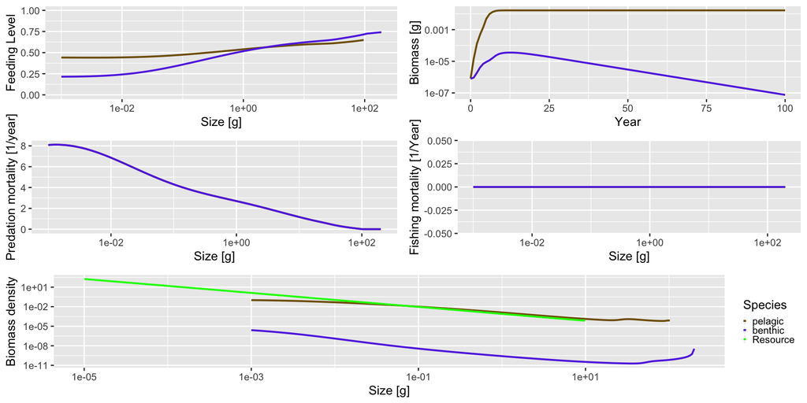

```r
sim2 <- project(params, t_max = 100, effort = 0)
plot(sim2)
```